# Joe Razo’s Dissertation Analyses

Joseph Razo, M.S.

Defended July 26, 2021

##### [Home](https://jrazo7063.github.io/Homepage.html) | [Machine Learning in mlr3](https://jrazo7063.github.io/mlr3.html) | [Data Cleaning](https://jrazo7063.github.io/Data-Cleaning.html) | [Count Dist.](https://www.youtube.com/watch?v=4rVyLQeVDI4) | [Data Visualization](https://www.youtube.com/watch?v=4hu7_zcG83Q)

The premise of my dissertation was centered on the idea that clinical providers have access to a wealth of patient information. However, we are not taking advantage of these data when tailoring treatment and evaluating program outcomes. There have been increased number of patients seeking Substance Use Disorder treatment, yet we are not successfully graduating nearly enough patients from programs to mitigate the overall public health impact.

Although clinical scientists have been mobilized to identify the effective treatment components aimed at improving outcomes, program graduation rates have stagnated. These scientists often rely on the generalized linear model (GLM) and statistical inference as the go-to statistical analysis tools. Though these approaches can be useful, their inherent assumptions and methods may not fully allow researchers to analyze all pertinent information available and may impact policy recommendations. This work presents an alternative statistcal framework and additional tools to facilitate greater analysis flexibility and accuracy within the Substance Use and Mental Health fields.

Disclaimer: *There are a few methodological steps I could have taken to improve the analyses that I have noticed as I continue to grow in my research and programming journey. I wanted to publish this as is to remain authentic as possible along my research and programming journey. There’s an old cliche saying, “A good dissertation is a done dissertation, a great dissertation is a published dissertation, and a perfect dissertation is neither.”*

# Data Cleaning

I will be comparing and contrasting common statistical inference techniques with statistical learning to better understand how the latter may be used within the SUD treatment field.

We will be using the SAMHSA Treatment Episode Dataset-Discharge (TEDS-D) from 2017. The dataset is available at this [website](https://www.datafiles.samhsa.gov/dataset/teds-d-2017-ds0001-teds-d-2017-ds0001) for easy of following along.

```r
library(tidyverse)

teds <- read_csv("tedsd_2017.csv", show_col_types = FALSE)
```

First thing I want to do is recode/create some of the primary SUD variables in my analysis. The first variable I created `Disch` stands for “Discharge” and represents whether an individual successfully discharged their treatment program. I defined successful discharge as either 1) Treatment was completed 2) Transferred to another treatment facility. Everything else was coded as an unsuccessful discharge

```r
teds<-teds%>%
  mutate(Disch = ifelse(teds$REASON == 1 | teds$REASON ==4,1,0),
         alcohol = case_when(
           teds$SUB1 == 2 ~ 1, # Alcohol is primary drug of choice
           teds$SUB2 == 2 ~ 2, # Alcohol is secondary drug of choice
           teds$SUB3 == 2 ~ 3, # Alcohol is tertiary drug of choice
           TRUE ~ 0),
         alcohol_Benzo = case_when(
           teds$SUB1 == 2 | teds$SUB1 == 13 | teds$SUB1 == 14 ~ 1,
           teds$SUB2 == 2 | teds$SUB2 == 13 | teds$SUB2 == 14 ~ 2,
           teds$SUB3 == 2 | teds$SUB3 == 13 | teds$SUB3 == 14 ~ 3,
           TRUE ~ 0),
         marijuana = case_when(
           teds$SUB1 == 4 ~ 1,
           teds$SUB2 == 4 ~ 2,
           teds$SUB3 == 4 ~ 3,
           TRUE ~ 0),
         Heroin = case_when(
           teds$SUB1 == 5 ~ 1,
           teds$SUB2 == 5 ~ 2,
           teds$SUB3 == 5 ~ 3,
           TRUE ~ 0),
         Her_Op = case_when(
           teds$SUB1 == 5 | teds$SUB1 == 7 ~ 1,
           teds$SUB2 == 5 | teds$SUB2 == 7 ~ 2,
           teds$SUB3 == 5 | teds$SUB3 == 7 ~ 3,
           TRUE ~ 0),
         stimulants = case_when(
           teds$SUB1 == 3 | teds$SUB1 >= 10 & teds$SUB1 <= 12 ~ 1,
           teds$SUB2 == 3 | teds$SUB2 >= 10 & teds$SUB2 <= 12 ~ 2,
           teds$SUB3 == 3 | teds$SUB3 >= 10 & teds$SUB3 <= 12 ~ 3,
           TRUE ~ 0),
         cocaine = case_when(
           teds$SUB1 == 3 ~ 1,
           teds$SUB2 == 3 ~ 2,
           teds$SUB3 == 3 ~ 3,
           TRUE ~ 0)
         )
```

In the above code, recoded the primary, secondary, and tertiary drug of choices as 1,2,3, respectively. Given that the TEDS dataset obtains very nuanced drug classifications, I combined certain categories with similar pharmacodynamics. For example, alcohol and benzodiazepines act on similar GABA receptors, therefore I combined these two classes into the `alcohol_Benzo` variable.

Next, I will use the same process to recode the rest of the variables needing transformation

```r
#Court Mandated Status & Setting
teds<-teds%>%
  mutate(Court = ifelse(teds$PSOURCE==7,1,0),
         detox = ifelse(teds$SERVICES==8|teds$SERVICES==1|teds$SERVICES==2,1,0),
         out_pt = ifelse(teds$SERVICES==6|teds$SERVICES==7,1,0),
         resid = ifelse(teds$SERVICES>=3 &teds$SERVICES<=5,1,0))
```

The `Court` variable is dichotomized to represent anyone who was referred to treatment by any court or legal entity. The setting variables are dummy coded, or one-hot encoded.

### Keeping Only Relevant Variables

Before we go any further in our data cleaning, let’s just select the relevant variables we will include in our analysis

```r
teds <- teds%>%
  dplyr::select(PSOURCE,LOS,NOPRIOR,ARRESTS,PSYPROB,DSMCRIT,EMPLOY,GENDER,AGE,RACE,
         ETHNIC,alcohol,marijuana,ROUTE1,ROUTE2,ROUTE3,Heroin,Her_Op,
         stimulants,FREQ1,FREQ2,FREQ3,FRSTUSE1,FRSTUSE2,FRSTUSE3,cocaine,
         alcohol_Benzo,out_pt,resid,Court,detox,Disch)
```

### Missing Data

Given the large size of the dataset, I decided to simply listwise delete cases. However, there were certain variables that didn’t make sense to listwise delete. For example, there were a significant number of people who did not endorse a tertiary drug of choice. Had we listwise deleted these individuals, our dataset would be much smaller and our sample biased.

```r
teds<- teds%>%
  mutate(LOS = replace(LOS,LOS==-9,0),
         ROUTE1 = replace(ROUTE1,ROUTE1==-9,0),
         ROUTE2 = replace(ROUTE2,ROUTE2==-9,0),
         ROUTE3 = replace(ROUTE3,ROUTE3==-9,0),
         FREQ1 = replace(FREQ1,FREQ1==-9,0),
         FREQ2 = replace(FREQ2,FREQ2==-9,0),
         FREQ3 = replace(FREQ3,FREQ3==-9,0),
         FRSTUSE1 = replace(FRSTUSE1,FRSTUSE1==-9,0),
         FRSTUSE2 = replace(FRSTUSE2,FRSTUSE2==-9,0),
         FRSTUSE3 = replace(FRSTUSE3,FRSTUSE3==-9,0))

teds[teds==-9]<-NA
teds<-na.omit(teds)
```

### Covnerting to factors

The TEDS dataset predominantly coded variables as numeric, even where variables represented categorical indices. I use a simple for loop along with the `factor()` function to coerce these variables into factors.

```r
x<- c(1,3:8,10,11,14:16,20:22,32)
teds<-as.data.frame(teds)
for (i in x){
  teds[,i]<-factor(teds[,i])
}
str(teds)
```

```
## 'data.frame':    803959 obs. of  32 variables:
##  $ PSOURCE      : Factor w/ 7 levels "1","2","3","4",..: 1 3 7 7 7 1 1 1 1 1 ...
##  $ LOS          : num  37 36 33 32 36 36 33 33 36 36 ...
##  $ NOPRIOR      : Factor w/ 2 levels "0","1": 2 2 1 2 1 1 1 1 2 2 ...
##  $ ARRESTS      : Factor w/ 3 levels "0","1","2": 1 1 1 2 1 1 2 1 1 1 ...
##  $ PSYPROB      : Factor w/ 2 levels "1","2": 1 2 2 1 2 1 2 1 1 2 ...
##  $ DSMCRIT      : Factor w/ 19 levels "1","2","3","4",..: 4 15 9 4 4 14 4 4 19 4 ...
##  $ EMPLOY       : Factor w/ 4 levels "1","2","3","4": 2 1 1 4 1 2 3 3 3 2 ...
##  $ GENDER       : Factor w/ 2 levels "1","2": 2 2 1 1 1 1 2 2 2 2 ...
##  $ AGE          : num  9 9 7 12 6 5 5 5 6 5 ...
##  $ RACE         : Factor w/ 9 levels "1","2","3","4",..: 5 5 5 1 8 5 1 1 1 1 ...
##  $ ETHNIC       : Factor w/ 5 levels "1","2","3","4",..: 4 4 4 4 4 4 4 4 4 4 ...
##  $ alcohol      : num  1 0 1 2 1 1 2 1 1 1 ...
##  $ marijuana    : num  0 0 0 1 2 0 0 0 2 0 ...
##  $ ROUTE1       : Factor w/ 6 levels "0","1","2","3",..: 2 3 2 3 2 2 3 2 2 2 ...
```

[output cut: 20 more lines]

# Analysis Plan

My aim was to mimic a general workflow of an academic researcher or program consultant. The first step would be to use a feature selection algorithm to select the variables that contribute the most to the outcome prediction. Second, build a model using those features. I also wanted to identify pros and cons of each approach throughout the analysis

As a result, I selected two feature selection algorithms, Stepwise Regression and LASSO regression, and 3 classification algorithms, logistic regression, GAM, and neural networks. After running the feature selection algorithms, I had 2 sets of variables, 1 from Stepwise Regression and 1 from LASSO regression. I then used these 2 variable sets in all 3 classification algorithms, totaling 6 classification models.

### Data splitting for analysis

Though `tidyverse` and other related packages have great functions to split data into training and testing sets, it made sense for me to simply create separate datasets for each analysis, given that multiple models would be ran for each algorithm.

```r
set.seed(2023)
split <- sample(1:5, nrow(teds), replace = TRUE)

teds.SR <- teds%>%filter(split==1)
teds.LAR <- teds%>%filter(split==2)
teds.LoR <- teds%>%filter(split==3)
teds.Sp <- teds%>% filter(split==4)
teds.NN <- teds%>% filter(split==5)

### Training/Test Sets
set.seed(2023)
SR.test = sample(160475,32095)
LAR.test = sample(160703,32141)
LoR.test = sample(160690,32138)
Sp.test = sample(161008, 32201)
NN.test = sample(161056, 32211)
```

# Feature Selection

We will use 2 feature selection algorithms, the Stepwise Regression, and the LASSO Regression. The goal is to compare and contrast the output variables from these analyses, specifically looking at model parsimony and mitigating the multicollinearity assumption. The remaining variables from each models will then be used seperately in the classification models for further analysis.  
## Stepwise Regression The first analysis I run is a stepwise regression. I use the `caret` package to train the model, using 10-fold cross-validation.

```r
library(caret)
library(MASS)
library(ellipsis)
library(e1071)
library(leaps)
library(glmnet)
```

```r
step.model<-train(Disch~., data= teds.SR[-SR.test,], family = "binomial",
                  method = "glmStepAIC",
                  trControl = trainControl(method = "cv", number = 10),
                  trace = FALSE)
## Note, this analysis took approximately 72hrs to complete
```

Our output should look something like this:

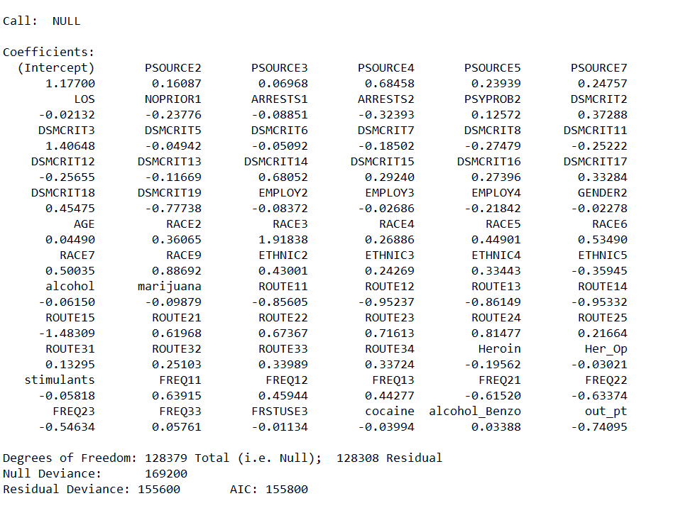

As a result, these variables will be included in the classification analyses.

## LASSO Regression

The LASSO Regression is our second and final feature selection algorithm. This equation is commonly referred to as a shrinkage algorithm, given the tendency for the L1 parameter to shrink coefficients to 0.

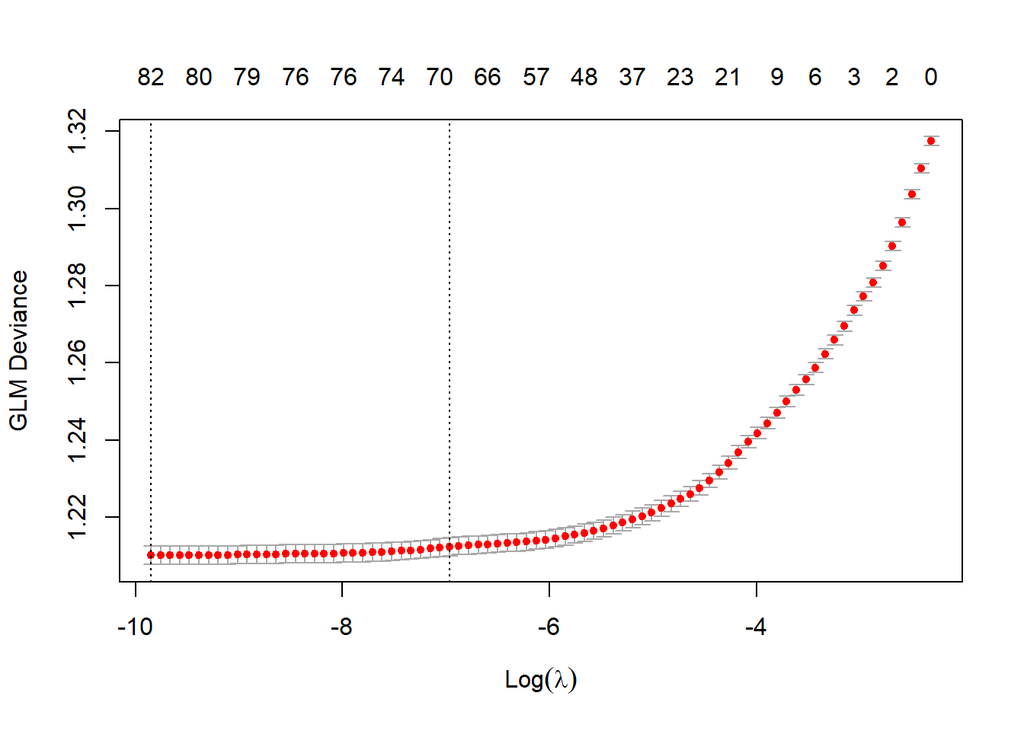

```r
#model prep
x=model.matrix(Disch~., teds.LAR)[,-1]
y=teds.LAR$Disch

###LASSO Model ###
grid = 10^seq(10,-2,length=100)
set.seed(1234)
cv.out<-cv.glmnet(x[-LAR.test,],y[-LAR.test], alpha = 1, family = binomial,
                  nfolds = 10)

plot(cv.out)
```

```r
bestlam<-cv.out$lambda.min

bestlam
```

```
## [1] 5.272371e-05
```

```r
##Testing set
out1=glmnet(x[LAR.test,],y[LAR.test], alpha = 1, lambda = grid, family = binomial)
lasso.coef1<- predict(out1,type = "coefficients",s=bestlam)[1:22,]

lasso.coef1[lasso.coef1!=0]
```

```
##  (Intercept)     PSOURCE6     PSOURCE7          LOS     NOPRIOR1     PSYPROB2
##  1.270996182 -0.050550356  0.001693521 -0.019755810 -0.116903657  0.052782391
##     DSMCRIT2     DSMCRIT3     DSMCRIT7
##  0.102521069  0.596625948 -0.081917806
```

Notice there are significanly less variables in the LASSO vs the Stepwise regression. Additionally, there are no risks of multi-collenarity. Our next assessment will see if the classification models with LASSO retained variables retain predictive accuracy with significantly less variables.

# Classificaion Models

The classification models we will evaluate are: *Logistic Regression*, *Spline Models*, and *Single Layer Feed Forward Neural Network*. Each algorithm will contain 2 models: 1 model using variables retained by **Stepwise Regression**, and 1 model using variables retained by **LASSO Regression**.  
Along with building the models for each, we will evaluate the predictive accuracy and idenfity pros and cons of each model. We will use 10-fold cross vailadation, as well as a 20% holdout test set. Area Under the Curve and Receiver/Operator Curve will be used to identify predictive accuracy for each model.

## Logistic Regression

Logistic regression is one of the most widely used classification algorithm in academia, and is a staple in industry as well. This algo is a favorite due to its high interpretability and scalability, and out of the box prediction accuracy is not bad either.  
The code is also very straight forward where we simply run the `glm()` function to train, and the `predict()` for testing. Note we are not using our typical 10-fold cross validation, but statistical inference instead. Going back to our problem at hand with evaluating large treatment data, this his typically what a program evaluator would use to evaluate medical/mental health data.

```r
library(pROC)
#Creating 2 datasets for stepwise and LASSO models
Step.LR <- subset(teds.LoR, select = c(PSOURCE,LOS, NOPRIOR, ARRESTS,PSYPROB,DSMCRIT,EMPLOY,GENDER,AGE,RACE,ETHNIC,alcohol,marijuana, ROUTE1,ROUTE2,ROUTE3,Heroin,Her_Op,stimulants,FREQ1,FREQ2,FREQ3,FRSTUSE3,cocaine, alcohol_Benzo, out_pt,Disch))

Las.LR <- subset(teds.LoR, select = c(PSOURCE,LOS,NOPRIOR,PSYPROB, DSMCRIT, Disch))

### Training Logistic Regression from Stepwise###
Step.logit.train<-glm(Disch~., data= Step.LR[-LoR.test,], family = binomial)

summary(Step.logit.train)
```

```
##
## Call:
## glm(formula = Disch ~ ., family = binomial, data = Step.LR[-LoR.test,
##     ])
##
## Deviance Residuals:
##     Min       1Q   Median       3Q      Max
## -2.7778  -1.1720   0.6937   0.9562   2.1513
##
## Coefficients:
##                Estimate Std. Error z value Pr(>|z|)
## (Intercept)    1.479799   0.150573   9.828  < 2e-16 ***
## PSOURCE2       0.113727   0.022885   4.969 6.71e-07 ***
## PSOURCE3       0.042189   0.022868   1.845 0.065054 .
## PSOURCE4       0.536841   0.110295   4.867 1.13e-06 ***
## PSOURCE5       0.252010   0.121754   2.070 0.038468 *
## PSOURCE6      -0.062176   0.021582  -2.881 0.003966 **
## PSOURCE7       0.270505   0.016663  16.234  < 2e-16 ***
## LOS           -0.020887   0.000489 -42.716  < 2e-16 ***
## NOPRIOR1      -0.226806   0.013242 -17.128  < 2e-16 ***
## ARRESTS1      -0.071863   0.025191  -2.853 0.004336 **
## ARRESTS2      -0.251808   0.058502  -4.304 1.68e-05 ***
## PSYPROB2       0.103481   0.012775   8.100 5.48e-16 ***
## DSMCRIT2       0.254515   0.095199   2.674 0.007506 **
## DSMCRIT3       1.252769   0.116536  10.750  < 2e-16 ***
## DSMCRIT4      -0.318623   0.084239  -3.782 0.000155 ***
## DSMCRIT5      -0.317811   0.085327  -3.725 0.000196 ***
## DSMCRIT6      -0.431375   0.088804  -4.858 1.19e-06 ***
## DSMCRIT7      -0.496652   0.087506  -5.676 1.38e-08 ***
## DSMCRIT8      -0.464542   0.086400  -5.377 7.59e-08 ***
## DSMCRIT9      -0.293440   0.088571  -3.313 0.000923 ***
## DSMCRIT10     -0.319536   0.090579  -3.528 0.000419 ***
## DSMCRIT11     -0.482131   0.097560  -4.942 7.74e-07 ***
## DSMCRIT12     -0.588095   0.099097  -5.935 2.95e-09 ***
## DSMCRIT13     -0.358303   0.110269  -3.249 0.001157 **
## DSMCRIT14      0.415681   0.131747   3.155 0.001604 **
## DSMCRIT15      0.149535   0.116768   1.281 0.200327
## DSMCRIT16     -0.293085   0.176711  -1.659 0.097206 .
## DSMCRIT17     -0.135140   0.144565  -0.935 0.349889
## DSMCRIT18      0.237039   0.288288   0.822 0.410947
```

[output cut: 46 more lines]

```
## FREQ33         0.191565   0.060882   3.146 0.001652 **
## FRSTUSE3       0.003941   0.007641   0.516 0.605987
## cocaine       -0.010959   0.012012  -0.912 0.361588
## alcohol_Benzo  0.036411   0.014491   2.513 0.011983 *
## out_pt        -0.723328   0.015533 -46.567  < 2e-16 ***
## ---
## Signif. codes:  0 '***' 0.001 '**' 0.01 '*' 0.05 '.' 0.1 ' ' 1
##
## (Dispersion parameter for binomial family taken to be 1)
##
##     Null deviance: 169663  on 128551  degrees of freedom
## Residual deviance: 156107  on 128472  degrees of freedom
## AIC: 156267
##
## Number of Fisher Scoring iterations: 5
```

```r
## Testing Logistic Regression from Stepwise###

Step.logit.test <-Step.LR[LoR.test,]
Step.logit.test$pred<- predict.glm(Step.logit.train, newdata = Step.LR[LoR.test,], type = "response")
Step.logit.test$Disch<-as.factor(Step.logit.test$Disch)

step.logit.auc <- auc(roc(Step.logit.test$Disch, Step.logit.test$pred))
step.logit.auc
```

```
## Area under the curve: 0.6833
```

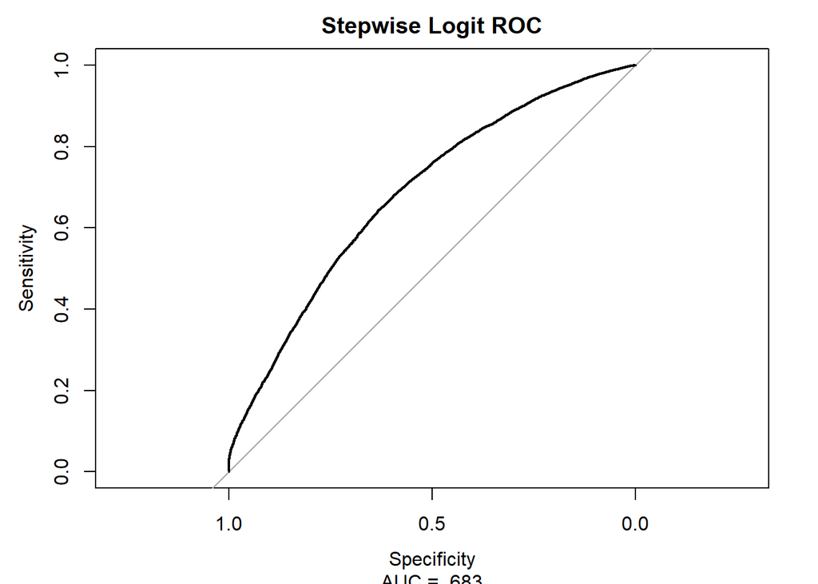

```r
plot(roc(Step.logit.test$Disch, Step.logit.test$pred), main = "Stepwise Logit ROC",
     sub = "AUC = .683")
```

```r
###### LASSO Logistic Regression ####
Las.logit.train <- glm(Disch~., data = Las.LR[-LoR.test,], family = binomial)
Las.logit.pred <- predict.glm(Las.logit.train, newdata = Las.LR[LoR.test,], type = "response")


### Testing Logistic Regression from LASSO
Las.logit.test <- Las.LR[LoR.test,]

Las.logit.test$pred<-Las.logit.pred

Las.logit.test$Disch<-as.factor(Las.logit.test$Disch)

Las.logit.auc<-auc(roc(Las.logit.test$Disch, Las.logit.test$pred))
Las.logit.auc
```

```
## Area under the curve: 0.6458
```

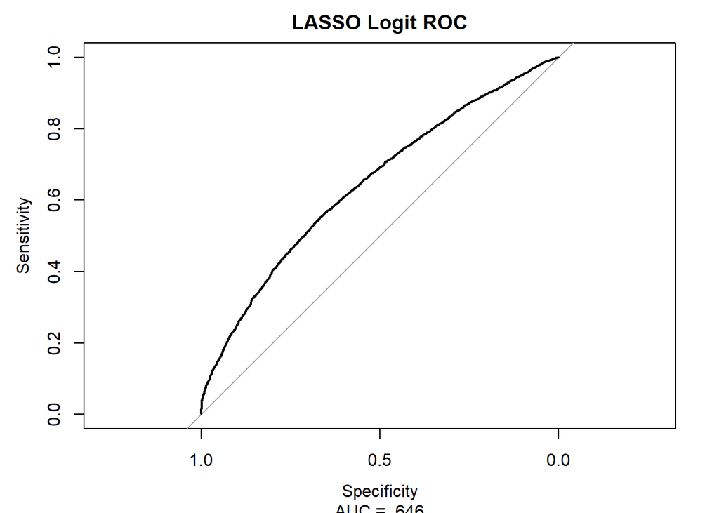

```r
plot(roc(Las.logit.test$Disch, Las.logit.test$pred), main = "LASSO Logit ROC",
     sub = "AUC = .646")
```

Both models performed well, with the following AUC’s:

| Stepwise | LASSO |
| --- | --- |
| 0.683 | 0.646 |

Additionally, the explicit coefficients makes this model very easy to interpret. This would be ideal if we would like to understand the relationship between each predictor variable (and interactions between variables) and the outcome.

## Spline Model

The next models we will run are the spline models. Splines are typically thought of as a regression analysis as opposed to classification, given the emphasis on non-linearity. However, if we conceptualize our categorical outcome instead as the log-odds of the positive case (treatment graduation), our “Y” becomes a continuous outcome. We then look to see whether there is a non-linear relationship between the predictor, and the log-odds of successful graduation.  
We will use 10-fold cross validation for this analysis to identify the appropiate degrees of freedom to place on our splines. We will then use this model to predict the outcomes on our holdout test dataset.

```r
library(splines)
library(boot)
Step.Sp <- subset(teds.Sp, select = c(PSOURCE,LOS, NOPRIOR, ARRESTS, PSYPROB, DSMCRIT, EMPLOY, GENDER,AGE,RACE,ETHNIC,alcohol, marijuana,  ROUTE1, ROUTE2, ROUTE3, Heroin, Her_Op, stimulants, FREQ1, FREQ2, FREQ3, FRSTUSE3, cocaine, alcohol_Benzo, out_pt,Disch))


### Stepwise Cross-Validation####
set.seed(1234)
cv.error.10<-rep(0,10)
for (i in 1:10) {
  step.gam.fit<-glm(Disch~ PSOURCE+ns(LOS,df=i)+NOPRIOR+ARRESTS+PSYPROB+DSMCRIT+EMPLOY+GENDER+
                      ns(AGE,df=i)+RACE+ETHNIC+alcohol+marijuana+ROUTE1+ROUTE2+
                    ROUTE3+Heroin+Her_Op+stimulants+FREQ1+FREQ2+FREQ3+ns(FRSTUSE3,df=i)+cocaine+alcohol_Benzo+out_pt,
                    data = Step.Sp[-Sp.test,], family = binomial)
  cv.error.10[i]<-cv.glm(Step.Sp[-Sp.test,],step.gam.fit,K=10)$delta[1]
}

cv.error.10
```

```
##  [1] 0.2099662 0.2092117 0.2083974 0.2078071 0.2076417 0.2076872 0.2072396
##  [8] 0.2070333 0.2068117 0.2065113
```

```r
### Stepwise Test ###
step.gam.test<-glm(Disch~ PSOURCE+ns(LOS,df=10)+NOPRIOR+ARRESTS+PSYPROB+DSMCRIT+EMPLOY+GENDER+
                    ns(AGE,df=10)+RACE+ETHNIC+alcohol+marijuana+ROUTE1+ROUTE2+
                    ROUTE3+Heroin+Her_Op+stimulants+FREQ1+FREQ2+FREQ3+ns(FRSTUSE3,df=10)+cocaine+alcohol_Benzo+out_pt,data = Step.Sp[Sp.test,], family = binomial)

step.spline.test<-Step.Sp[Sp.test,]
step.spline.test$pred <- predict.glm(step.gam.test,newdata = Step.Sp[Sp.test,],
                             type = "response", family=binomial)

### AUC/ROC ###
library(AUC)
step.spline.test$Disch <- as.factor(step.spline.test$Disch)

step.sp.auc <- auc(roc(step.spline.test$pred, step.spline.test$Disch))
step.sp.auc
```

```
## [1] 0.7067658
```

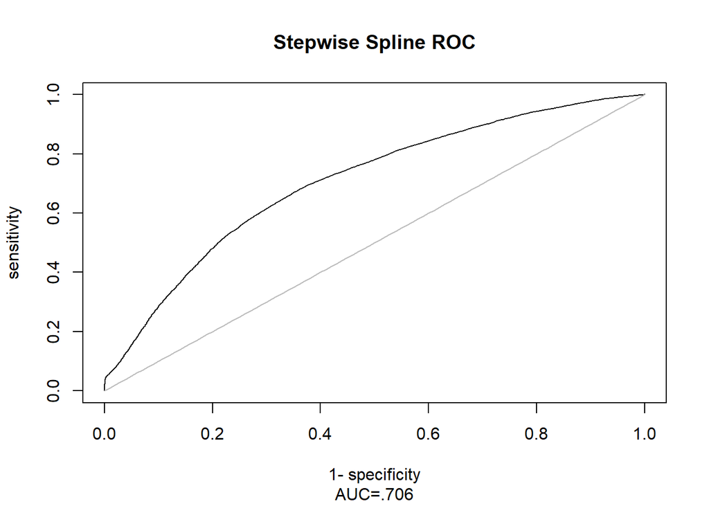

```r
plot(roc(step.spline.test$pred, step.spline.test$Disch), main="Stepwise Spline ROC",
     sub="AUC=.706")
```

```r
################### LASSO GAM######################

Las.spline <- subset(teds.Sp, select = c(PSOURCE, LOS, NOPRIOR, PSYPROB, DSMCRIT, Disch))

### LASSO Spline Training ###
set.seed(1234)
La.cv.error.10<-rep(0,10)

for (i in 1:10) {
  Las.fit<-glm(Disch~PSOURCE+NOPRIOR+ns(LOS,df=i)+PSYPROB+DSMCRIT,
               data= Las.spline[-Sp.test,], family=binomial)
  La.cv.error.10[i]<-cv.glm(Las.spline[-Sp.test,],Las.fit,K=10)$delta[1]
}

sink(file = "Lasso.Spline.errors.6_17.txt")
La.cv.error.10
```

```
##  [1] 0.2181522 0.2180470 0.2175346 0.2173432 0.2173859 0.2172924 0.2165620
##  [8] 0.2165129 0.2163302 0.2163099
```

```r
sink()
### Lasso Test
Lass.test<-glm(Disch~PSOURCE+NOPRIOR+ns(LOS,df=10)+PSYPROB+DSMCRIT,
                        data= Las.spline[Sp.test,], family=binomial)

Lass.gam.test<-Las.spline[Sp.test,]
Lass.gam.test$pred <- predict.glm(Lass.test,newdata = Las.spline[Sp.test,],
                             type = "response", family=binomial)

### AUC/ROC
Lass.gam.test$Disch<-as.factor(Lass.gam.test$Disch)

Lass.sp.auc <- auc(roc(Lass.gam.test$pred, Lass.gam.test$Disch))
Lass.sp.auc
```

```
## [1] 0.654958
```

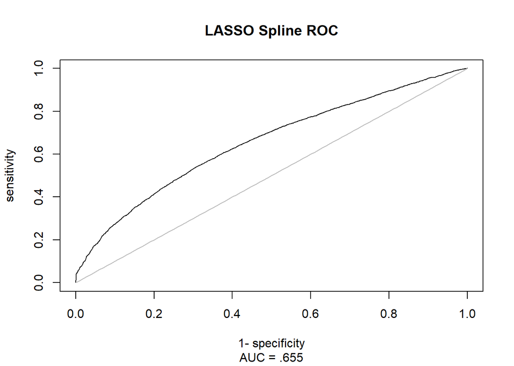

```r
plot(roc(Lass.gam.test$pred, Lass.gam.test$Disch), main = "LASSO Spline ROC",
     sub = "AUC = .655")
```

The spline models performed only slightly better than the logistic regression.

| Stepwise | LASSO |
| --- | --- |
| 0.707 | 0.655 |

This may indicate there are no non-linear relationships between the predictors and the log-odds of successful treatment completion. With respect to the pros and cons, the spline models can be much more accurate than a logistic regression analysis, particularly for non-linear relationships. However, we give up a degree of interpretability when running the spline, as we are not able to interpret coefficients quite as easy as a simple logistic regression.

## Neural Network

The last model we will run is a single layer feed forward neural network. These classes of models are generally known to be the most accurate models within the statistical learning scope, and are very scalable into deep neural networks.  
The code starts by specifying the necessary tuning parameters.The `trainControl` function is part of the `caret` package, which allows the user to specify the validation process and desired output type (in our case, 10-fold cross validation, using the probability the individual is in each of the 2 classes).The `expand.grid()` function is part of the base package, and it allows us to set a grid of possible hyperparameter values. We use the `decay` values, which can be thought of penalizing parameters to combat overfitting. The `size` argument refers to the number of nodes in our model. Here we opt to try out 3 to 12 nodes in our model. The `numWts` formula is used to calculate the maximum number of possbile parameters our model my estimate, if we selected the largest possible network.

```r
library(nnet)
library(caret)
Step.Net <- subset(teds.NN, select = c(PSOURCE,LOS, NOPRIOR, ARRESTS, PSYPROB, DSMCRIT, EMPLOY,GENDER, AGE,RACE,ETHNIC,alcohol,marijuana,  ROUTE1, ROUTE2, ROUTE3, Heroin,Her_Op,stimulants,FREQ1,FREQ2,FREQ3, FRSTUSE3, cocaine, alcohol_Benzo, out_pt,Disch))

Las.net <- subset(teds.NN, select = c(PSOURCE, LOS, NOPRIOR, PSYPROB, DSMCRIT, Disch))

##### Stepwise Training ###
x = model.matrix(Disch~., Step.Net)[,-1]
y = Step.Net$Disch
ctrl <- trainControl(method = "cv", number = 10,
                     summaryFunction = twoClassSummary,classProbs = TRUE)
nnetGrid <-expand.grid(decay =c(0, .01,.05,.1),
                       size = seq(from = 3, to = 12, by =1))
maxSize <- max(nnetGrid$.size)
numWts <- 1*(maxSize*(ncol(x)+1)+maxSize+1)
Step.Net$Disch<-as.factor(Step.Net$Disch)
Step.Net$Disch<-make.names(Step.Net$Disch, unique = FALSE)
Step.net.train <- train(x=x[-NN.test,], y = Step.Net$Disch[-NN.test],
                       method = "nnet", metric = "ROC",preProcess = c("scale"),
                       tuneGrid = nnetGrid,
                       trControl = ctrl, maxit = 2000,MaxNwts=numWts,
                       lineout = FALSE)

### Stepwise Testing ###
Step.nn.test <- nnet(x= x[NN.test,], y=y[NN.test], data = Step.Net[NN.test,],
                    size = 10, decay = .1, maxit = 2000)
Step.nn.tdata <- Step.Net[NN.test,]
Step.nn.tdata$pred <-Step.nn.test$fitted.values
Step.nn.tdata$Disch<- as.factor(Step.nn.tdata$Disch)
Step.nn.auc <- auc(roc(Step.nn.tdata$pred, Step.nn.tdata$Disch))
Step.nn.auc

plot(roc(Step.nn.tdata$pred, Step.nn.tdata$Disch), main = "Stepwise Neural Network",
     sub = "AUC = .783")

##### LASSO Training ###
ctrl <- trainControl(method = "cv", number = 10,
                     summaryFunction = twoClassSummary,classProbs = TRUE)
nnetGrid <-expand.grid(decay =c(0, .01,.05,.1),
                       size = seq(from = 3, to = 12, by =1))
maxSize <- max(nnetGrid$.size)
numWts <- 1*(maxSize*(ncol(x)+1)+maxSize+1)
x = model.matrix(Disch~., Las.net)[,-1]
y = Las.net$Disch
Las.net$Disch<-as.factor(Las.net$Disch)
Las.net$Disch<-make.names(Las.net$Disch, unique = FALSE)
Las.net.train <- train(x=x[-NN.test,], y = Las.net$Disch[-NN.test],
                        method = "nnet", metric = "ROC",preProcess = c("scale"),
                        tuneGrid = nnetGrid,
                        trControl = ctrl, maxit = 2000,MaxNwts=numWts,
                        lineout = FALSE)

### LASSO Testing ###
Las.nn.test <- nnet(formula = Disch~., data = Las.net[NN.test,],
                    size = 12, decay = .05, maxit = 2000)
Las.nn.tdata <- Las.net[NN.test,]
Las.nn.tdata$pred <-Las.nn.test$fitted.values
summary(Las.nn.test)
las.nn.auc <- auc(roc(Las.nn.tdata$pred, Las.nn.tdata$Disch))
las.nn.auc

plot(roc(Las.nn.tdata$pred, Las.nn.tdata$Disch), main = "LASSO Neural Network",
     sub = "AUC = .705")
```

As we can see the neural network significantly increased the predictive accuracy as outlined below:

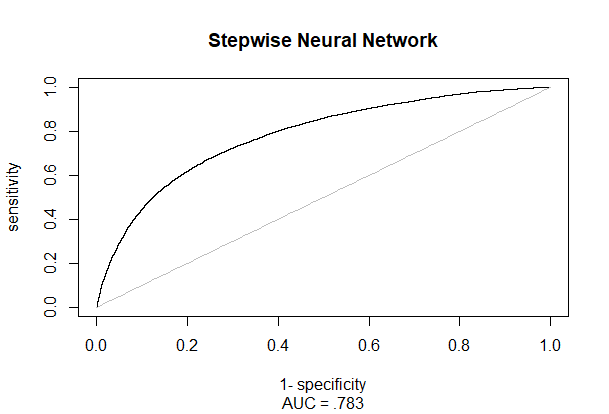

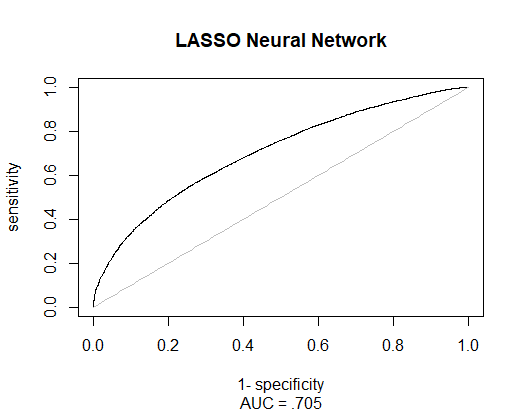

[output not shown]

However, one major drawback to any neural network is the interpretability of the model. There is no way of knowing, based off these models, which varaiable or vairables contributed the most to the accuracy. This model may have great real-world implications if we would like to best identify clients that may need extra support during treatment if they are predicted to have a lower likelihood of successful treatment outcomes.